# Frontpage

Resubmission of "Opgavesæt O1"

Date 29/09/2023

Group 12

Members:

Oscar Damgaard Nielsen 201811388

Bjarke Justesen Karlsen 202010613

My-Thanh Thi Le 202006329

# SWMAL Exercise

## § 2 "End-to-End Machine Learning Project" [HOML]

#### Resume: Look at the Big Picture

You have to frame the problem, and figure out what you are trying to solve. What is the core issue? Is it a reggression or classification task? Furthermore you have to select performance messures. fx Accuracy isn't very good when evaluating a digit evaluator. finally you have to check your assumptions. If you assume it is a regression task, but find out it is converted to a classification task down stream. Then that really sucks.

#### Resume: Get the Data

This segment talks about how to use jupyter notebooks which is presumed to be the thing we should skip summarising. When you aquire your data you should take a look at a few elements to ensure you know what types of data you are dealing with. The method describe() or hist can also give som standard statistical analysis to help you get a feel for the data. At this stage you should also create you test set, by shuffling the data and setting about 20% aside for testing. It needs to be shuffled so the algorithm doesn't just figure out every number is larger than the last fx. You should seed your shuffling so you get the same one each time. Otherwise if you train an algorithm on the same set several times it will end up knowing the whole set. You also need to ensure you data is representative of the true data population, otherwise you should consider stratifying your dataset.

#### Resume: Explore and Visualize the Data to Gain Insights,

This segment is about data exploration and visualization to grain insight in the data. We have to get a more in depth about the data, which only do for the traing sets. It is a good idea to visualize the data through heatmaps/histograms. You may need to set the opacity down or color different segment for finding the patterns. You will also have to look at the correlations between the different value, but only if the dataset is not too large. The correlation coefficient ranges -1 to 1 and if the correlation is close to -1 or 1 it tells there is correlation between the data. Zero mean there is no linear correlation. The last part of this segment is about experiment with attribute combinations. Some atrributes maybe don't make sence they stand alone, so maybe combine them.

#### Resume: Select and Train a Model

You are now ready to select and train a model. Firstly try a simple model as linear regression, however some values may be way off. These data can be hard to understand, so we are going to use some tools for validation. This is can be MAE or RMSE. Another problem with the data if examples used the k-nearstnieghbor is overfitting or underfitting the training data. The main way to fix underfitting is try using a more complex model and how it proforms. The problem can also be the data is too small and one way to help simulate more date is it use the k-fold cross-validation, it spilt the data into nonoverlapping subsets. The model can now traing for every subsets and all the different score for each subsets put together give a value for its preformance.

#### Resume: Fine-Tune Your Model

After training the models, we have to fine tune the. For finetuning the model, you can manually try to find a great combination for the hyperparameter. Or use the GridSearchCV if you have a few hyperparameter or the RandomizedSearchCV for testing alot of hyperparameter.

Another way to fine-tune your system is combine the models that performs best as a group. This mothod is called the Ensemble. It will often preform better the individual models.

You may need to look into your best models and understand their errors. It can be some of the features don't make sense to have, so maybe you want to drop them. Or maybe it is because you are missing some features and need more data. May need to look into outliers.

When you system if preforming well on the train set, it may be time to try evaluating your system on the test set. After testing you will need to evalute the scores. The system may proferm really good on the test set or not. If it doesn't you may need to go back and finetune even more. If the system preform very well, then may need to make it ready for launch.

#### Resume: Launch, Monitor, and Maintain Your System

If your system came to this step, you will need to get it ready for production. For a system to go into it need to be launch, monitor and maintain. This can be done differenly ways. First way is that you can create documentation and conduct tests and integrate it. The alternative approach is using a model on cloud platform.

It is not the last step to just deploying it. You will have to collect new fresh data and keep training the model and evaluating performance. It is import to catch potiontial issuses early. It is also a good idea to have a backup of the models in a database. The models can end up being corrupted.

#### Resume: Try It Out!.

Now you have read all the a both segment, you will have a understanding of what machine learning project look like. You can now see how much goes into making a grate system. The machine learning algorigthms are important, however it is preferable to be comfortable with the hole process.

SWMAL Opgave

## Dataanalyse

Denne opgave er skrevet på dansk efter aftale med Carsten

### Qa) Beskrivelse af datasæt til O4 projekt

I forbindelse med vores O4 projekt har vi valgt at arbejde med image recognition. Vi vil udvikle en model, som kan analysere og identificere de forskellige vejrforhold på billeder. Dette kan være Cloudy, Rainy, Sunny eller Sunrise. For at opnå dette mål vil vi at bruge en klassifikationsmetode, hvor billeder kategoriseres, så vores model kan trænes til at forudsige vejret, når det præsenteres med et nyt billede.

Vi står over for en multi-class image classification-opgave, da der er fire forskellige vejrtilstande, som skal genkendes. Denne opgave vil blive løst ved hjælp af supervised learning, hvor vi træner vores model vha. et datasæt

For at lave denne model har vi hentet data fra kaggle, som er en platform, der udbyder store dataset. Vi har et datasæt som består af ca. 1200 billeder, opdelt i de 4 kategorier. Der vil være ca. 300 samples pr. kategori til at træne/teste vores model. Disse samples består af forskellige billeder, som hver især illustrerer en af de fire kategorier af vejr, Sunny, Rainy, Cloudy og Sunrise, som vil være vores target værdier.

Datasættet vil derfor blive opdelt i tre sæt: træningssæt til at træne modellen, valideringssæt til at finjustere modelparametre og teste ydeevnen, og testsæt til endelig evaluering af modellen.

Når vi arbejder med image recognition, kan det være lidt sværere at identificere fejl i dataene. Der kan forekomme eventuelle fejl og usikkerheder i form af belysning, synsvinkler eller andre faktorer, som vil påvirke billedernes kvalitet. Det kan også være, at et af billederne er havnet i den forkerte kategori i træningssættet, altså er der fejl i labels. På denne måde vil vores model ikke trænes korrekt til at predict vores targetværdier. Der vil blive lavet en dataanalyse af vores datasæt for at identificere korrupte data.

Dette projekt sigter altså mod at udvikle en image recognition-model til at identificere vejrforhold på billeder ved hjælp af supervised learning.

### Qb) Dataanalyse af eget datasæt

Her opsættes dataanalysen, som forklares i slutningen af denne opgave.

```python
#make function to fetch dataset

import cv2
import os
import numpy as np
import matplotlib.pyplot as plt


def getDataSet(categories: list, folder: str):
    images = []
    labels = []
    for category in categories:
        folder_path = os.path.join(folder, category)
        label = categories.index(category)  # Assign a numerical label to each category
        for filename in os.listdir(folder_path):
            if filename.endswith(".jpg"):
                img_path = os.path.join(folder_path, filename)
                img = cv2.imread(img_path)
                if img is not None:
                    img = cv2.resize(img, (128, 128))  # Resize to a common size
                    img = img / 255.0  # Normalize pixel values to [0, 1]
                    images.append(img)
                    labels.append(label)
                else:
                    print(f"Failed to load image: {img_path}")
    return images, labels
```

Der er implementeret en funktion getDataSet(), som tager en liste med kategorier og en string, som er navnet på mappen. Den vil give hvert image et label baseret på kategori, og index. Derudover vil den præprocesserer billederne, og sorterer de korrupte filer fra.

```
Data              dataanalyse.ipynb pipelines.ipynb   weather_dataset
Failed to load image: weather_dataset/Shine/shine131.jpg
Failed to load image: weather_dataset/Rain/rain141.jpg
```

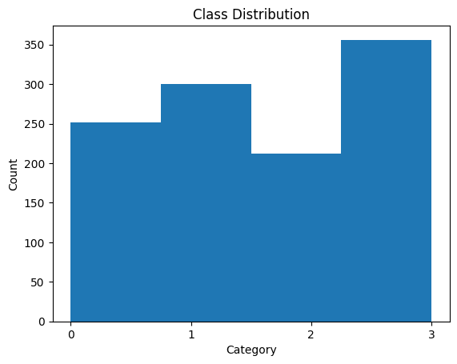

```
Category for image 0: Shine
```

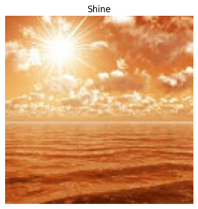

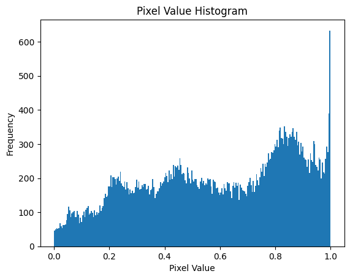

```python
import cv2
import os
import numpy as np
import matplotlib.pyplot as plt

! ls
# ! dir
data_folder = "weather_dataset"
categories = ["Shine", "Cloudy", "Rain", "Sunrise"]


images, labels = getDataSet(categories, data_folder)

# Convert the lists to NumPy arrays
images = np.array(images)
labels = np.array(labels)

# Assuming 'labels' is a list or NumPy array of category labels
# You can create histograms of the labels to visualize the class distribution
plt.hist(labels, bins=len(np.unique(labels)))  # Use as many bins as unique labels
plt.xlabel('Category')
plt.ylabel('Count')
plt.title('Class Distribution')
plt.xticks(np.unique(labels))  # Set x-ticks to unique class labels
plt.show()

# Assuming 'images' is a NumPy array containing the image data
# You can create a histogram of pixel values for one image (e.g., the first image)
print(f"Category for image 0: {categories[labels[0]]}")

plt.imshow(images[0])
plt.axis('off')  # Optional: Turn off the axis labels and ticks
plt.title(categories[labels[0]])
plt.show()

plt.hist(images[0].ravel(), bins=256, range=(0, 1))  # Assuming normalized pixel values in [0, 1]
plt.xlabel('Pixel Value')
plt.ylabel('Frequency')
plt.title('Pixel Value Histogram')
plt.show()
```

Der er lavet to histrogrammer. Et til at give en oversigt over hvor meget data, der er til hver kategori, og et til at vise pixel feature på et billede.

Efter frafiltreringen af de billeder der ikke kunne loades ses det på histogrammet, at der er mellem 200-350 billeder inden for hver kategori. Dette vurderer vi til at være en tilstrækkelig mængde af hver kategori til at kunne træne en billedgenkender og stadig have 100 billeder tilovers til testing.

Der er valgt at lave et histogram for image[0], som hører under kategorien "Shine". På dette histogram kan vi se hvordan frekvens af pixels på billedet er fordelt ud over pixel value 0-1. Pixel value viser hvor mørke eller lyse farverne på pixelsne er, hvor 0 er helt mørkt og 1 er helt hvidt.

På histogrammet ser vi, at der er størst frekvens ved Pixel value 1, samt at frekvensen stiger mere value. Dette giver god mening, da billedet skal repræsentere Shine, som gerne skulle være meget lyst. Histogrammet stemmer derfor overens med billedet.

# SWMAL Exercise

## Pipelines

$$ \newcommand\rem[1]{} \rem{SWMAL: CEF def and LaTeX commands, remember: no newlines in defs} \newcommand\eq[2]{#1 &=& #2\\} \newcommand\ar[2]{\begin{array}{#1}#2\end{array}} \newcommand\ac[2]{\left[\ar{#1}{#2}\right]} \newcommand\st[1]{_{\scriptsize #1}} \newcommand\norm[1]{{\cal L}_{#1}} \newcommand\obs[2]{#1_{\text{\scriptsize obs}}^{\left(#2\right)}} \newcommand\diff[1]{\text{d}#1} \newcommand\pown[1]{^{(#1)}} \def\pownn{\pown{n}} \def\powni{\pown{i}} \def\powtest{\pown{\text{\scriptsize test}}} \def\powtrain{\pown{\text{\scriptsize train}}} \def\bX{\mathbf{M}} \def\bX{\mathbf{X}} \def\bZ{\mathbf{Z}} \def\bw{\mathbf{m}} \def\bx{\mathbf{x}} \def\by{\mathbf{y}} \def\bz{\mathbf{z}} \def\bw{\mathbf{w}} \def\btheta{{\boldsymbol\theta}} \def\bSigma{{\boldsymbol\Sigma}} \def\half{\frac{1}{2}} $$ We are going to implement a min/max scaler for a multilayer perceptron (MLP). The MLP is designed to receive input data within specific ranges: `[0;1]` or `[-1;1]`. The min/max scaler will adjust the data accordingly, ensuring that it falls within the expected range and preventing saturation to the minimum or maximum values.

```python
%matplotlib inline

import sys
import pickle
import numpy as np
import matplotlib.pyplot as plt

from sklearn.neural_network import MLPRegressor
from sklearn.linear_model import LinearRegression
from sklearn.metrics import r2_score

def LoadDataFromL01():
    filename = "Data/itmal_l01_data.pkl"
    with open(f"{filename}", "rb") as f:
        (X, y) = pickle.load(f)
        return X, y

X, y = LoadDataFromL01()

print(f"X.shape={X.shape},  y.shape={y.shape}")

assert X.shape[0] == y.shape[0]
assert X.ndim == 2
assert y.ndim == 1  # did a y.ravel() before saving to picke file
assert X.shape[0] == 29

# re-create plot data (not stored in the Pickel file)
m = np.linspace(0, 60000, 1000)
M = np.empty([m.shape[0], 1])
M[:, 0] = m

print("OK")
```

```
X.shape=(29, 1),  y.shape=(29,)
OK
```

```
The MLP may mis-fit the data, seen in the, sometimes, bad R^2 score..

lin.reg.score(X, y)=0.73
    MLP.score(X, y)=-48656.97

OK
```

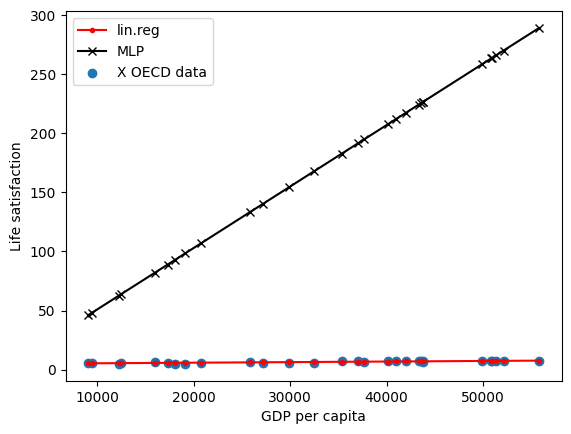

```python
# Setup the MLP and lin. regression again..

def isNumpyData(t: np.ndarray, expected_ndim: int):
    assert isinstance(expected_ndim, int), f"input parameter 'expected_ndim' is not an integer but a '{type(expected_ndim)}'"
    assert expected_ndim>=0, f"expected input parameter 'expected_ndim' to be >=0, got {expected_ndim}"
    if t is None:
        print("input parameter 't' is None", file=sys.stderr)
        return False
    if not isinstance(t, np.ndarray):
        print("excepted numpy.ndarray got type '{type(t)}'", file=sys.stderr)
        return False
    if not t.ndim==expected_ndim:
        print("expected ndim={expected_ndim} but found {t.ndim}", file=sys.stderr)
        return False
    return True

def PlotModels(model1, model2, X: np.ndarray, y: np.ndarray, name_model1: str, name_model2: str):

    # NOTE: local function is such a nifty feature of Python!
    def CalcPredAndScore(model, X: np.ndarray, y: np.ndarray,):
        assert isNumpyData(X, 2) and isNumpyData(y, 1) and X.shape[0]==y.shape[0]
        y_pred_model = model.predict(X)
        score_model = r2_score(y, y_pred_model) # call r2
        return y_pred_model, score_model

    assert isinstance(name_model1, str) and isinstance(name_model2, str)

    y_pred_model1, score_model1 = CalcPredAndScore(model1, X, y)
    y_pred_model2, score_model2 = CalcPredAndScore(model2, X, y)

    plt.plot(X, y_pred_model1, "r.-")
    plt.plot(X, y_pred_model2, "kx-")
    plt.scatter(X, y)
    plt.xlabel("GDP per capita")
    plt.ylabel("Life satisfaction")
    plt.legend([name_model1, name_model2, "X OECD data"])

    l = max(len(name_model1), len(name_model2))

    print(f"{(name_model1).rjust(l)}.score(X, y)={score_model1:0.2f}")
    print(f"{(name_model2).rjust(l)}.score(X, y)={score_model2:0.2f}")

# lets make a linear and MLP regressor and redo the plots
mlp = MLPRegressor(hidden_layer_sizes=(10, ),
                   solver='adam',
                   activation='relu',
                   tol=1E-5,
                   max_iter=100000,
                   verbose=False)
linreg = LinearRegression()

mlp.fit(X, y)
linreg.fit(X, y)

print("The MLP may mis-fit the data, seen in the, sometimes, bad R^2 score..\n")
PlotModels(linreg, mlp, X, y, "lin.reg", "MLP")
print("\nOK")
```

### Qa) Create a Min/max scaler for the MLP

This first version we are creating is the default version si most simplified solution. Here we take the max and min value from X. From that we are calculating the standardization.

Now we can re-train the MLP and re-plot with the preprocess data.

```
maxvalue=55805.204000000005
minvalue=9054.914
The MLP may mis-fit the data, seen in the, sometimes, bad R^2 score..

lin.reg.score(X, y)=0.73
    MLP.score(X, y)=0.73

OK
```

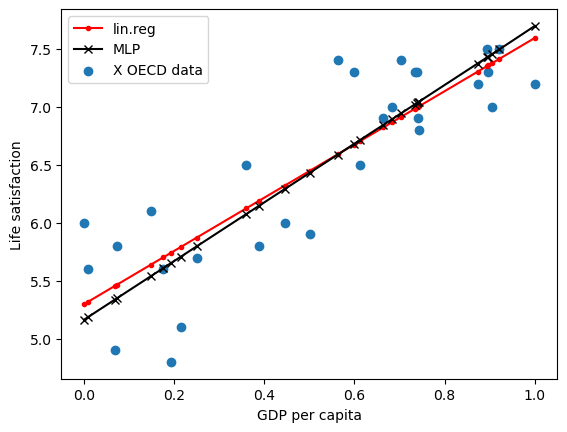

```python
maxvalue= X.max()
print(f"maxvalue={maxvalue}")
minvalue= X.min()
print(f"minvalue={minvalue}")

X_scaled = (X-minvalue)/(maxvalue-minvalue)

mlp.fit(X_scaled, y)
linreg.fit(X_scaled, y)
print("The MLP may mis-fit the data, seen in the, sometimes, bad R^2 score..\n")
PlotModels(linreg, mlp, X_scaled, y, "lin.reg", "MLP")
print("\nOK")
```

### Qb) Scikit-learn Pipelines

Now, we will perform the re-scaling again, this time using a pipeline and a scaler from sklearn. We will be utilizing sklearn.pipeline.Pipeline and sklearn.preprocessing.MinMaxScaler. The pipeline acts as an intelligent composite constructor, which reduces the number of variables involved. This is achieved by directly passing the scaled values into the model we intend to train. This is done by calling the `pipe.fit()`.

Again we are using the `PlotModels()` function to retraing the linear regressor on the scaled data.

```
lin.reg.score(X, y)=0.73
    MLP.score(X, y)=0.72
```

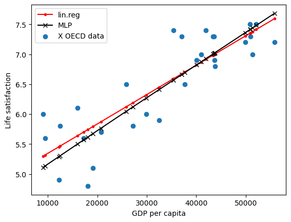

```python
from sklearn.pipeline import Pipeline
from sklearn.preprocessing import MinMaxScaler

pipe = Pipeline(
    [
        ('Scaler', MinMaxScaler()),
        ('mlp',mlp)
    ]
)
pipe.fit(X, y)
linreg.fit(X, y)
PlotModels(linreg, pipe, X, y, "lin.reg", "MLP")
```

### Qc) Outliers and the Min-max Scaler vs. the Standard Scaler

The fundamental problem with the min/max scaler is it linearly transforms the data to fit within a specified range `[0;1]` or `[-1;1]`. This means the min and max value often can be set by outliers and can cause the data to be distortion of the overall distribution. It can be a single outliers with an extremly low value, the min/max scaler will strech to fit the one outlier. So the rest of the data is getting a more narrow range, this can lead to potentially losing important information.

On the other hand we have the standard scaler, which is less sensitive to ouliers. This is because the standard scale preforms z-score normalization, which is part of statics. In other words this processs center the data around 0 and scales it based on its variance. So the bigger standard variance the less influence on the scaling.

```
lin.reg.score(X, y)=0.73
    MLP.score(X, y)=0.80
```

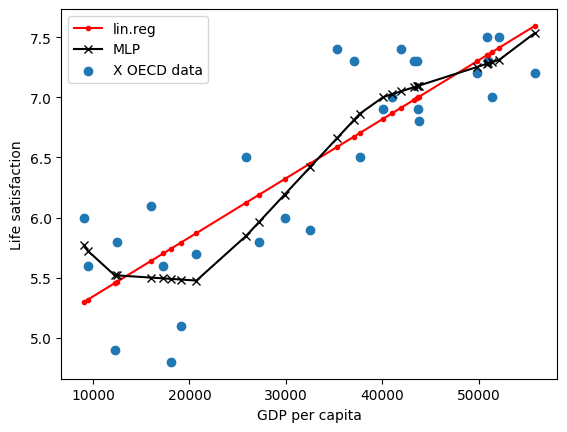

```python
from sklearn.preprocessing import StandardScaler

pipe = Pipeline([('Scaler', StandardScaler()), ('mlp',mlp)])

pipe.fit(X, y)
linreg.fit(X, y)
PlotModels(linreg, pipe, X, y, "lin.reg", "MLP")
```

### Qd) Modify the MLP Hyperparameters

Now we want to try chaning the different hyperparametes associated with the MLP. We are going to try chaning the amount of neurons, solver and the activation. We will use the $R^2$. to check if the output still is sensible.

Firstly try new amount of neurons, we are chaning from 10 to 5.

```
lin.reg.score(X, y)=0.73
    MLP.score(X, y)=0.73
```

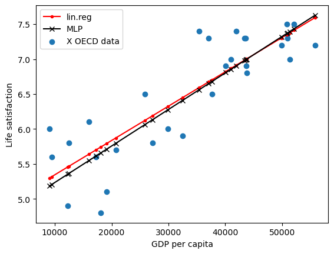

```python
from sklearn.pipeline import Pipeline
from sklearn.preprocessing import MinMaxScaler

mlp = MLPRegressor(hidden_layer_sizes=(5, ),
                   solver='adam',
                   activation='relu',
                   tol=1E-5,
                   max_iter=100000,
                   verbose=False)


pipe = Pipeline(
    [
        ('Scaler', MinMaxScaler()),
        ('mlp',mlp)
    ]
)
pipe.fit(X, y)
linreg.fit(X, y)
PlotModels(linreg, pipe, X, y, "lin.reg", "MLP")
```

We can observe that the MLP still prefromce fine with 5 neurons. So we are now testing for only one neurons.

```
lin.reg.score(X, y)=0.73
    MLP.score(X, y)=0.70
```

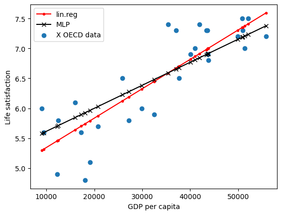

```python
from sklearn.pipeline import Pipeline
from sklearn.preprocessing import MinMaxScaler

mlp = MLPRegressor(hidden_layer_sizes=(1, ),
                   solver='adam',
                   activation='relu',
                   tol=1E-5,
                   max_iter=100000,
                   verbose=False)


pipe = Pipeline(
    [
        ('Scaler', MinMaxScaler()),
        ('mlp',mlp)
    ]
)
pipe.fit(X, y)
linreg.fit(X, y)
PlotModels(linreg, pipe, X, y, "lin.reg", "MLP")
```

The $R^2$ is only a little amount worse than the linear regression.

Now we are going to try using a new activation functions. This is a mathematical operations applied to the output of a neuron in a neural network. This helps introducing a non-linearity into the network. This allows the neural network to learn and model complex relationships btween input and output. We are using the logistic also called simoid function. The Formula is $$ \ar{rl}{ f(x) &= \frac{1}{1+(e)^{-x}} } $$

The formula output range is between `[0;1]`

```
lin.reg.score(X, y)=0.73
    MLP.score(X, y)=0.72
```

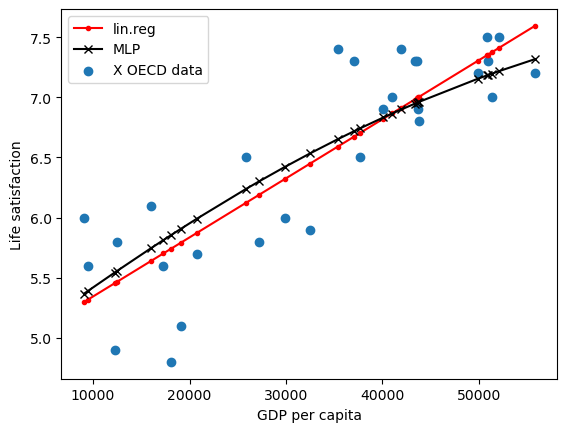

```python
mlp = MLPRegressor(hidden_layer_sizes=(10, ),
                   solver='adam',
                   activation='logistic',
                   tol=1E-5,
                   max_iter=100000,
                   verbose=False)
pipe = Pipeline(
    [
        ('Scaler', MinMaxScaler()),
        ('mlp',mlp)
    ]
)
pipe.fit(X, y)
linreg.fit(X, y)
PlotModels(linreg, pipe, X, y, "lin.reg", "MLP")
```

Chaning the activation function to be logistic the $R^2$ is only a little amount worse than the linear regression. You can obsever the shape is non-linear.

Now we want to try to use a different solver. We are going with the stochastic gradient descent`sgd` instead of the `adam`. This is a algorithm that is often use in matchine learning. It is a variant of the standard gradient descent algorithm.

```
lin.reg.score(X, y)=0.73
    MLP.score(X, y)=0.50
```

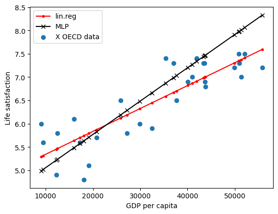

```python
mlp = MLPRegressor(hidden_layer_sizes=(10, ),
                   solver='sgd',  # Try different solvers
                   activation='relu',
                   tol=1E-5,
                   max_iter=100000,
                   verbose=False)
pipe = Pipeline(
    [
        ('Scaler', MinMaxScaler()),
        ('mlp',mlp)
    ]
)
pipe.fit(X, y)
linreg.fit(X, y)
PlotModels(linreg, pipe, X, y, "lin.reg", "MLP")
```

# SWMAL Exercise

## Training a Linear Regressor I

The goal of the linear regression is to find the argument $w$ that minimizes the sum-of-squares error over all inputs.

$$ \def\rem#1{} \rem{ITMAL: CEF def and LaTeX commands, remember: no newlines in defs} \def\eq#1#2{#1 &=& #2\\} \def\ar#1#2{\begin{array}{#1}#2\end{array}} \def\ac#1#2{\left[\ar{#1}{#2}\right]} \def\st#1{_{\textrm{\scriptsize #1}}} \def\norm#1{{\cal L}_{#1}} \def\obs#1#2{#1_{\textrm{\scriptsize obs}}^{\left(#2\right)}} \def\diff#1{\mathrm{d}#1} \def\pown#1{^{(#1)}} \def\pownn{\pown{n}} \def\powni{\pown{i}} \def\powtest{\pown{\textrm{\scriptsize test}}} \def\powtrain{\pown{\textrm{\scriptsize train}}} \def\bX{\mathbf{M}} \def\bX{\mathbf{X}} \def\bZ{\mathbf{Z}} \def\bw{\mathbf{m}} \def\bx{\mathbf{x}} \def\by{\mathbf{y}} \def\bz{\mathbf{z}} \def\bw{\mathbf{w}} \def\btheta{{\boldsymbol\theta}} \def\bSigma{{\boldsymbol\Sigma}} \def\half{\frac{1}{2}} \def\pfrac#1#2{\frac{\partial~#1}{\partial~#2}} \def\dfrac#1#2{\frac{\mathrm{d}~#1}{\mathrm{d}#2}} \bw^* ~=~ \left( \bX^\top \bX \right)^{-1} \bX^\top \by $$

#### Qa Write a Python function that uses the closed-form to find $\bw^*$

We are going to make a function `GetTheNormalEquation(X, y)`. The function takes a training dataset, where we have the matrix`X` and the vector of the label `y` and returns the `w` via the closed-form.

The function is going to to use the normal equation as presented below:

$$ \bw^* ~=~ \left( \bX^\top \bX \right)^{-1} \bX^\top \by $$

Inside the function we make a variable called X_b which is the concatenate column of ones to X. In other words it adds the bias term.

Use the test data, `X` and `y` in the code below to find `w` via the closed-form. Use the test vectors for `w` to test your implementation, and remember to add the bias term (concat an all-one vector to `X` before solving).

The next line where we store variable `w` we simply use the normal equation. It constists of multiple parts. The `np.linalg.inv()` calculates the inverse of the matrix obtained from the $$ \left( \bX^\top \bX \right)^{-1} $$.

The product of `np.linalg.inv()` is multiplied with the rest, which is the transpose of the input data matrix with the target output vector. It results in a vector of size (d+1).

$$ \bX^\top \by $$

```python
import sys,os
sys.path.append(os.path.expanduser('../'))
import numpy as np
from libitmal import utils as itmalutils

def GetOS():
    return dir if os.name == 'nt' else ls

# The Normal Equation p.134
def GetTheNormalEquation(X, y):
    X_b = np.c_[np.ones((X.shape[0], 1)), X]  # Concatenate a column of ones to X
    w = np.linalg.inv(X_b.T @ X_b) @ (X_b.T) @ (y)
    return w

def GenerateData():
    X = np.array([[8.34044009e-01],[1.44064899e+00],[2.28749635e-04],[6.04665145e-01]])
    y = np.array([5.97396028, 7.24897834, 4.86609388, 3.51245674])
    return X, y

X, y = GenerateData()

w = GetTheNormalEquation(X, y)


# TEST VECTOR:
w_expected = np.array([4.046879011698, 1.880121487278])
itmalutils.PrintMatrix(w, label="w=", precision=12)
itmalutils.AssertInRange(w, w_expected, eps=1E-9)

print("OK")
```

```
w=[4.046879011698 1.880121487278]
OK
```

#### Qb Find the limits of the least-square method

The problem with calculating of a matrix inverse can be compationally expensive. This is especially the case for larger or nearly singular matrices. A nearly singular matrix is one that is almost singular, which means it does not have a true inverse.

The reason it takes such a long time is the computational complexity, meaning doubling the number of features then you have to multiply the computation time be rougly 2<sup>2.4</sup>

```python
from sklearn.linear_model import LinearRegression

def GenerateData(M, N):
    # TEST DATA: Matrix, taken from [HOML]
    print(f'GenerateData(M={N}, N={N})...')

    assert M>0
    assert N>0
    assert isinstance(M, int)
    assert isinstance(N, int)

    # NOTE: not always possible to invert a random matrix;
    #       it becomes sigular, hence a more elaborate choice
    #       of values below (but still a hack):
    X=2 * np.ones([M, N])
    for i in range(X.shape[0]):
        X[i,0]=i*4
    for j in range(X.shape[1]):
        X[0,j]=-j*4

    y=4 + 3*X + np.random.randn(M,1)
    y=y[:,0] # well, could do better here!

    return X, y

X, y = GenerateData(M=10000, N=20)

w = GetTheNormalEquation(X, y)

# Print w
itmalutils.PrintMatrix(w, label="w=", precision=12)


print("OK")
```

```
GenerateData(M=20, N=20)...
w=[ 1666387.5502728098          2.440137876938   364127.55597364274
   -1027466.0868604467    -355721.375006271       54929.827803658765
    -379931.0885377476      82890.96006455205   -260862.72574724632
      10940.279039915009  -169174.47809120276    433595.0309961927
    -130711.1726267726     275061.5205127626     -50454.66184441206
    -149800.39751745152    107994.28902418479     91549.58807911839
       4787.796794080489    37335.08970069502    -43486.08680883595 ]
OK
```

# SWMAL Exercise

## Gradient Descent Methods and Training

$$ \def\rem#1{} \rem{ITMAL: CEF def and LaTeX commands, remember: no newlines in defs} \def\eq#1#2{#1 &=& #2\\} \def\ar#1#2{\begin{array}{#1}#2\end{array}} \def\ac#1#2{\left[\ar{#1}{#2}\right]} \def\st#1{_{\textrm{\scriptsize #1}}} \def\norm#1{{\cal L}_{#1}} \def\obs#1#2{#1_{\textrm{\scriptsize obs}}^{\left(#2\right)}} \def\diff#1{\mathrm{d}#1} \def\pown#1{^{(#1)}} \def\pownn{\pown{n}} \def\powni{\pown{i}} \def\powtest{\pown{\textrm{\scriptsize test}}} \def\powtrain{\pown{\textrm{\scriptsize train}}} \def\bX{\mathbf{M}} \def\bX{\mathbf{X}} \def\bZ{\mathbf{Z}} \def\bw{\mathbf{m}} \def\bx{\mathbf{x}} \def\by{\mathbf{y}} \def\bz{\mathbf{z}} \def\bw{\mathbf{w}} \def\btheta{{\boldsymbol\theta}} \def\bSigma{{\boldsymbol\Sigma}} \def\half{\frac{1}{2}} \def\pfrac#1#2{\frac{\partial~#1}{\partial~#2}} \def\dfrac#1#2{\frac{\mathrm{d}~#1}{\mathrm{d}#2}} $$

### Qa The Gradient Descent Method (GD)

Gradient descent is a generic optimization algorithm capable of finding optimal solutions to a wide range of problems. Which means it is an iterative optimization algorithm used to find the minimum of a function. The function used in this case is the cost function `J(w)`. The idea is based on taking steps proportional to the negative of the gradient of the function at the current point

The code below firstly imports all the libraries. Secondly theres is created a new function `GenerateData()` and the function returns 3 values `X, X_b, y`. `GenerateData()` generates random data for a linear regression where `X` represents a matrix of input features and `y` represents the target values. And atlast we have the `X_b` and it is the augmented feature matrix with the bias term.

The `eta` is the learning rate, which is the steps the algorithm takes towards finding the minimum of the cost function. If `eta` is too large, the algorithm may overshoot the minimum, which can potentially causing it to keep bouncing around near the minimum without settling down or it never reach a stable minimum and keeps running indefinitely. Conversely, if `eta` is too small, the algorithm may take a very long time to it never reach a stable minimum and keeps running indefinitely or get stuck in a local minimum.

The `n_iterations` is the number of epochs also called iterations. The `m` is the number of samples The `theta` is the intial random initializtaion

Inside the forloop we calculate the compute gradients of MSE with respect to theta and then we update the using the gradients and learning rate. This is repeated for the number of iterations.

See the pictures below on the left the learning rate is too low, and will eventually reach the solution, however it takes a long time. The middle the learning rate is looks pretty good, because we can see in a few iterations it has already found a good solution. On the rigth the learning rate is too high, which mean the algorithm diverges. The algorithm is getting further and futher away from the solution.

```
stochastic gradient descent theta=[4.14149307 2.81305367]
```

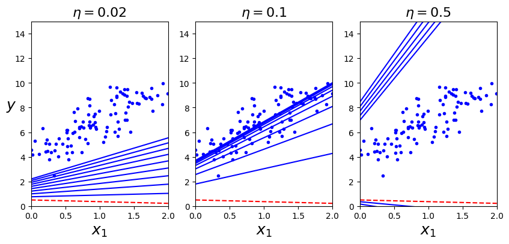

```
OK
```

```python
# NOTE: modified code from [GITHOML], 04_training_linear_models.ipynb

%matplotlib inline
import matplotlib as mpl
import matplotlib.pyplot as plt
import numpy as np
from sklearn.linear_model import LinearRegression

def GenerateData():
    X = 2 * np.random.rand(100, 1)
    y = 4 + 3 * X + np.random.randn(100, 1)
    #X_b represents a matrix of input features
    X_b = np.c_[np.ones((100, 1)), X]  # add x0 = 1 to each instance
    return X, X_b, y

X, X_b, y = GenerateData()

eta = 0.1 # learning rate
n_iterations = 1000 #num of epochs/iterations
m = 100 # num of samples
theta = np.random.randn(2,1) # random initialization

for iteration in range(n_iterations):
    # Compute gradients of MSE with respect to theta
    gradients = 2/m * X_b.T.dot(X_b.dot(theta) - y)
    # Update theta using the gradients and learning rate

    theta = theta - eta * gradients

print(f'stochastic gradient descent theta={theta.ravel()}')

##########################################################
# rest of the code is just for plotting, needs no review

def plot_gradient_descent(theta, eta, theta_path=None):
    m = len(X_b)
    plt.plot(X, y, "b.")
    n_iterations = 1000
    for iteration in range(n_iterations):
        if iteration < 10:
            y_predict = X_new_b.dot(theta)
            style = "b-" if iteration > 0 else "r--"
            plt.plot(X_new, y_predict, style)

        gradients = 2/m * X_b.T.dot(X_b.dot(theta) - y)
        theta = theta - eta * gradients
        if theta_path is not None:
            theta_path.append(theta)
    plt.xlabel("$x_1$", fontsize=18)
    plt.axis([0, 2, 0, 15])
    plt.title(r"$\eta = {}$".format(eta), fontsize=16)

np.random.seed(42)
theta_path_bgd = []
theta = np.random.randn(2,1)  # random initialization

X_new = np.array([[0], [2]])
X_new_b = np.c_[np.ones((2, 1)), X_new]  # add x0 = 1 to each instance

plt.figure(figsize=(10,4))
plt.subplot(131); plot_gradient_descent(theta, eta=0.02)
plt.ylabel("$y$", rotation=0, fontsize=18)
plt.subplot(132); plot_gradient_descent(theta, eta=0.1, theta_path=theta_path_bgd)
plt.subplot(133); plot_gradient_descent(theta, eta=0.5)
plt.show()

print('OK')
```

### Qb The Stochastic Gradient Descent Method (SGD)

Stochastic Gradient Descent is a variant of the Gradient Descaent. The main problem with the Gradient Descent is it uses the whole training set and it is really slow. Wheras the SGD is the opposite. SGD takes a random instance in the training set at every step and computes the gradient based only on the single instance. The problem with the SGD will over time be very closed to the minimum, however will continue to bounce around and never settle down.

The `np.random.randint(m)` generate a random integer between `[0;m)`. In the context `m` is the total number of data points in the traning set.

The main differens in the code is the extra forloop in the SGD compared to the GD. This extra forloop iteraters over all elements in the `X_b`. Another distinction lies in how the gradients are calculated. In GD, they are divided by m. These two reasons are connected since in SGD, we compute gradients each time we go through the for loop.

The `theta` is calculated the same way, however the gradint is changed

```
for epoch in range(n_epochs):
    for i in range(m):
        .
        .
        .
        gradients = 2 * xi.T.dot(xi.dot(theta) - yi)
        eta = ...
        theta = ...
```

where it for the GD method was just

```
for iteration in range(n_iterations):
    gradients = 2/m * X_b.T.dot(X_b.dot(theta) - y)
    theta = ..
```

```
stochastic gradient descent theta=[4.13232694 2.79527929]
Scikit-learn SGDRegressor "thetas": sgd_reg.intercept_=[4.09914528], sgd_reg.coef_=[2.87331758]
```

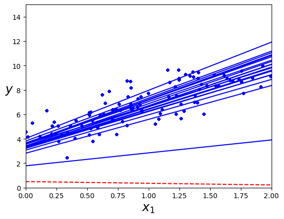

```
OK
```

```python
# NOTE: code from [GITHOML], 04_training_linear_models.ipynb

theta_path_sgd = []
m = len(X_b)
np.random.seed(42)

n_epochs = 50
t0, t1 = 5, 50  # learning schedule hyperparameters

def learning_schedule(t):
    return t0 / (t + t1)

theta = np.random.randn(2,1)  # random initialization

for epoch in range(n_epochs):
    for i in range(m):
        if epoch == 0 and i < 20:
            y_predict = X_new_b.dot(theta)
            style = "b-" if i > 0 else "r--"
            plt.plot(X_new, y_predict, style)

        random_index = np.random.randint(m)
        xi = X_b[random_index:random_index+1]
        yi = y[random_index:random_index+1]

        gradients = 2 * xi.T.dot(xi.dot(theta) - yi)
        eta = learning_schedule(epoch * m + i)
        theta = theta - eta * gradients
        theta_path_sgd.append(theta)

        plt.plot(X, y, "b.")

from sklearn.linear_model import SGDRegressor
#sgd_reg = SGDRegressor(max_iter=50, tol=-np.infty, penalty=None, eta0=0.1, random_state=42)
sgd_reg = SGDRegressor(max_iter=50, penalty=None, eta0=0.1, random_state=42)
sgd_reg.fit(X, y.ravel())
print(f'stochastic gradient descent theta={theta.ravel()}')
print(f'Scikit-learn SGDRegressor "thetas": sgd_reg.intercept_={sgd_reg.intercept_}, sgd_reg.coef_={sgd_reg.coef_}')

##########################################################
# rest of the code is just for plotting, needs no review
plt.xlabel("$x_1$", fontsize=18)
plt.ylabel("$y$", rotation=0, fontsize=18)
plt.axis([0, 2, 0, 15])

plt.show()

print('OK')
```

### Qc Adaptive learning rate for $\eta$

Another thing you can do with the `SGDRegressor` is set the learning rate to constant or adative in the hyperparameter.

```
SGDRegressor(max_iter=1,
             eta0=0.0005,
             learning_rate="constant", # or 'adaptive' etc.
             random_state=42)
```

### Qd Mini-batch Gradient Descent Method

The mini-batch gradient descent combines the best aspects of SGD and GD. The mini batch will start with taking random numbes as the SGD and escape from local minima. When the mini-batch is near the global mimimums, it will use the GD method, which is taking steps proportional to the negative of the gradient of the function at the current point

The main advantage of mini batch GD over the SGD you get a preformce boost from the optimization of matrix operations.

The main different is the MGD iterates tough the data in a mini-batches of 20 data at the time, whereas the GD proceses the entire dataset at once and the SGD is only processes one data point at a time. The gradients computation is now devided by the size of the minibatch. From the SGD we introduce the learning rate and it helps to decreases the learning rate as the number of iterations increases. The `theta_path_mgd` appends the each `theta` from each training.

```python
# NOTE: code from [GITHOML], 04_training_linear_models.ipynb
import numpy as np
theta_path_mgd = []

n_iterations = 50
minibatch_size = 20

np.random.seed(42)
theta = np.random.randn(2,1)  # random initialization

t0, t1 = 200, 1000
def learning_schedule(t):
    return t0 / (t + t1)

t = 0
for epoch in range(n_iterations):
    shuffled_indices = np.random.permutation(m)
    X_b_shuffled = X_b[shuffled_indices]
    y_shuffled = y[shuffled_indices]
    for i in range(0, m, minibatch_size):
        t += 1
        xi = X_b_shuffled[i:i+minibatch_size]
        yi = y_shuffled[i:i+minibatch_size]

        gradients = 2/minibatch_size * xi.T.dot(xi.dot(theta) - yi)
        eta = learning_schedule(t)
        theta = theta - eta * gradients
        theta_path_mgd.append(theta)

print(f'mini-batch theta={theta.ravel()}')
print('OK')
```

```
mini-batch theta=[4.04995397 2.7175486 ]
OK
```

### Qe Choosing a Gradient Descent Method

GD is good to get to the minimum, however it can be stuck in local minimum (if they occur). In the pictures below there is at lot of blue computation, which is expensive in a large datasets.

SGD is fast to convergence due to the frequent parameter update and is good for large datasets as it only processes one data point at a time. The problem with the SGD is willl over time be very close to the minimum, however will continues bounce around and never settel down.

MGD as is a compromise between GD and SGD. The only bad thing about is it requires tuning of batch size as a hyperparameter. The picture below illustate a good use of the MGD

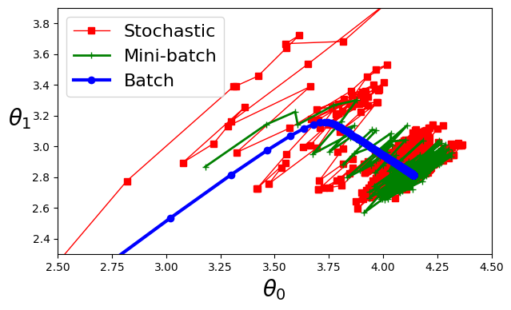

```
OK
```

```python
# NOTE: code from [GITHOML], 04_training_linear_models.ipynb

theta_path_bgd = np.array(theta_path_bgd)
theta_path_sgd = np.array(theta_path_sgd)
theta_path_mgd = np.array(theta_path_mgd)

plt.figure(figsize=(7,4))
plt.plot(theta_path_sgd[:, 0], theta_path_sgd[:, 1], "r-s", linewidth=1, label="Stochastic")
plt.plot(theta_path_mgd[:, 0], theta_path_mgd[:, 1], "g-+", linewidth=2, label="Mini-batch")
plt.plot(theta_path_bgd[:, 0], theta_path_bgd[:, 1], "b-o", linewidth=3, label="Batch")
plt.legend(loc="upper left", fontsize=16)
plt.xlabel(r"$\theta_0$", fontsize=20)
plt.ylabel(r"$\theta_1$   ", fontsize=20, rotation=0)
plt.axis([2.5, 4.5, 2.3, 3.9])
plt.show()
print('OK')
```

# SWMAL Exercise

## Artificial Neural Networks as Universal Approximators

In this exercise we will test the function of ANN as an universal approximator. We will use a simply ANN consisting of two neurons in a hidden layer.

We use the `tanh` activation function in the neuron. It can only approximate similar to a monotonic function. When we apply two neurons in a pair, they would be able to approximate an up-hill-then-downhill non monotonic function. This is a function with a single maximum.

Notice the lack of a train-test split in the exercise; since we only want to look at the approximation capabilities of the MLP, the train-test split is omitted, (and you are welcome to do the split yourself, and also to add noise in the data generators.)

```
OK
```

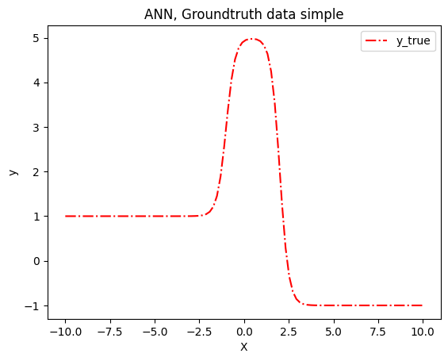

```python
# One data generator just to test out the MLP..
#   An MLP with just two neurons should be able to approximate this simple
#   down-up graph using its two non-linear sigmoid or tanh neurons...

import matplotlib.pyplot as plt
import numpy as np

def GenerateSimpleData():
    X = np.linspace(-10, 10, 100)
    y = 2*np.tanh(2*X - 12) - 3*np.tanh(2*X - 4)
    y = 2*np.tanh(2*X + 2)  - 3*np.tanh(2*X - 4)
    X = X.reshape(-1, 1) # Scikit-algorithms needs matrix in (:,1)-format
    return X,y

X, y_true = GenerateSimpleData()
plt.plot(X, y_true, "r-.")
plt.legend(["y_true"])
plt.xlabel("X")
plt.ylabel("y")
plt.title("ANN, Groundtruth data simple")

print("OK")
```

#### Qa)

We will fit the data generator and MLP in the layer 2. Them `y_true` and `y_pred` are plotted in a graph

```python
# Create MLP and fit model, just run..

from sklearn.neural_network import MLPRegressor

mlp = MLPRegressor(activation = 'tanh',      # activation function
                   hidden_layer_sizes = [2], # layes and neurons in layers: one hidden layer with two neurons
                   alpha = 1e-5,             # regularization parameter
                   solver = 'lbfgs',         # quasi-Newton solver
                   max_iter=10000,
                   verbose = True)

mlp.fit(X, y_true)
y_pred = mlp.predict(X)

# Extract weights and biases
weights = mlp.coefs_

biases = mlp.intercepts_
print("weights:")
print(weights)
print("biases:")
print(biases)

print("OK")
```

```
weights:
[array([[-1.99985578, -1.99966008]]), array([[ 3.00008787],
       [-2.00001444]])]
biases:
[array([ 3.9997559 , -1.99924065]), array([-3.0659848e-05])]
OK
```

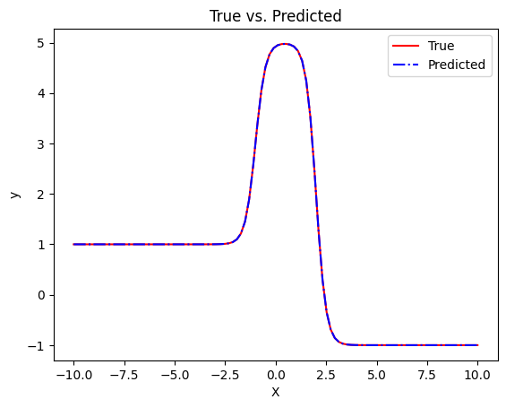

```python
import matplotlib.pyplot as plt

plt.plot(X, y_true, "r", label="True")
plt.plot(X, y_pred, "b-.", label="Predicted")
plt.legend()
plt.xlabel("X")
plt.ylabel("y")
plt.title("True vs. Predicted")
plt.show()
```

#### Qb)

This drawing below illustrates the ANN with its input-, hidden- and output-layer

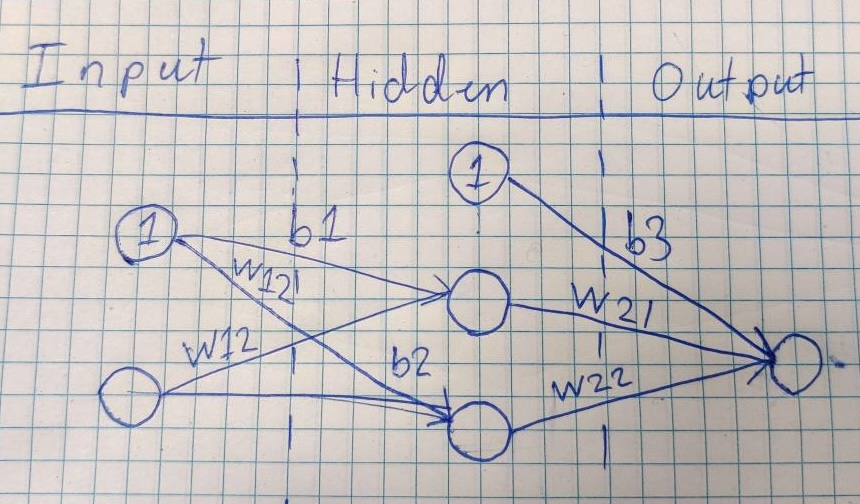

```python
from IPython.display import Image

Image(filename="./Figs/ANN_drawing.jpg", width=500, height=500)
```

#### Qc)

First we extract the weights and biases into individual parameters so we can use them for the formula. Thereafter we use the formula:

```
 activationFunction(weight*x+bias)
```

to find the output for each individual neuron.

```
For x = 1.5, y_math = [4.28461614]
mlp_sample_prediction:
[4.28461614]
```

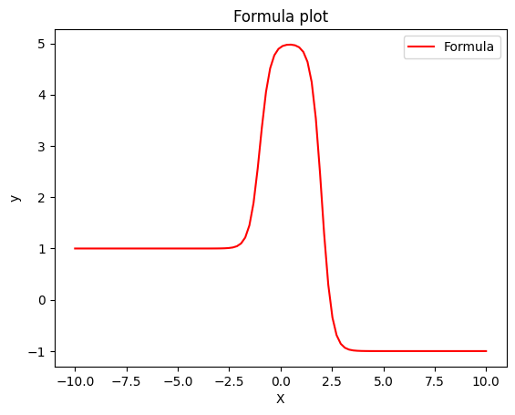

```python
# Extracted weights and biases
import numpy as np
# Extract the weights and biases
w11, w12 = weights[0][0]
w21 = weights[1][0]
w22 = weights[1][1]

b1, b2 = biases[0]
b3 = biases[1][0]

# Define the mathematical formula
def network_formula(x):
    return (w21*np.tanh(w11*x+b1) + w22*np.tanh(w12*x+b2))+b3

# Test the formula with a sample input
x_sample = 1.5
y_sample = network_formula(x_sample)

print(f"For x = {x_sample}, y_math = {y_sample}")

mlp_sample_prediction= mlp.predict([[x_sample]])

print("mlp_sample_prediction:")
print(mlp_sample_prediction)


plt.plot(X, network_formula(X), "r", label="Formula")
plt.legend()
plt.xlabel("X")
plt.ylabel("y")
plt.title("Formula plot")
plt.show()
```

As we can see from the sample we get exactly the same from the formula as from the MLP prediction, and when we plot it it looks just like the MLP plot

#### Qd)

Here we compare the Math formula with the MLP-predicted values as well as the ground truth. We can see that they are almost exactly alike.

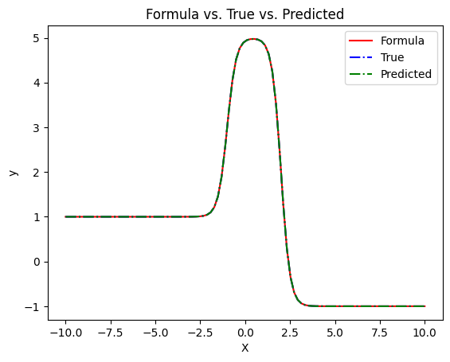

```python
plt.plot(X, network_formula(X), "r", label="Formula")
plt.plot(X, y_true, "b-.", label="True")
plt.plot(X, y_pred, "g-.", label="Predicted")
plt.legend()
plt.xlabel("X")
plt.ylabel("y")
plt.title("Formula vs. True vs. Predicted")
plt.show()
```

#### Qe)

Here we plot the function for just the first neuron, just the second as well as the sum of the two + the bias.

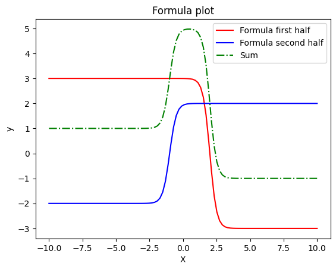

```python
def network_formula_first_half(x):
    return (w21*np.tanh(w11*x+b1))

def network_formula_second_half(x):
    return (w22*np.tanh(w12*x+b2))

sum = network_formula_first_half(X) + network_formula_second_half(X) +b3
plt.plot(X, network_formula_first_half(X), "r", label="Formula first half")
plt.plot(X, network_formula_second_half(X), "b", label="Formula second half")
plt.plot(X, sum, "g-.", label="Sum")
plt.legend()
plt.xlabel("X")
plt.ylabel("y")
plt.title("Formula plot")
plt.show()
```

On the plot we can see that the graph for the individual neurons in the MLP exhibit traits very similar to a monotonic tanh activation function since they both go exclusivlely one direction. However they go in the oposite direction, and therefore it totals to the correct function. This works since the function isn't very complex, but if we had to analyze a more complex system we would need more neurons who would all have traits like these and then it would total to the more complex function.

#### Qf)

Here is the data for a more complex function we need to analyze.

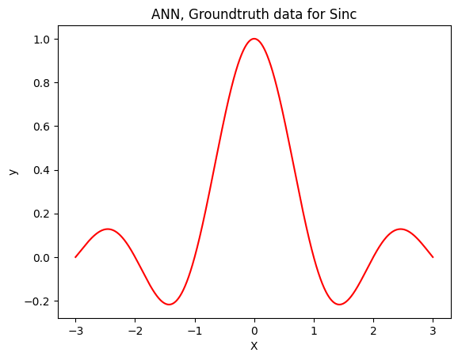

```python
def GenerateSincData():
    # A Sinc curve, approximation needs more neurons to capture the 'ringing'...
    X = np.linspace(-3, 3, 1000)
    y = np.sinc(X)
    X = X.reshape(-1,1)
    return X, y

X, y_true = GenerateSincData()
plt.plot(X, y_true, "r-")
plt.xlabel("X")
plt.ylabel("y")
plt.title("ANN, Groundtruth data for Sinc")
```

The data generator is changed to a function, that needs a NN with a higher capacity than the previous simple data. Therfore we increased the number of hidden layers to 5 and the amount of neurons per layer to 10 totalling to 50 hidden neurons compared to the 2 in the previous MLP.

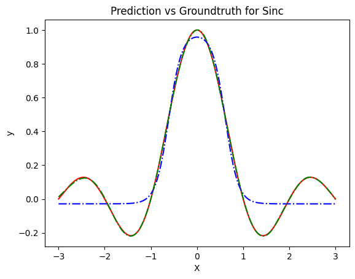

```python
mlp2 = MLPRegressor(activation = 'tanh',      # activation function
                   hidden_layer_sizes = [10,10,10,10,10], # layes and neurons in layers: 5 hidden layers with 5 neurons
                   alpha = 1e-5,             # regularization parameter
                   solver = 'lbfgs',         # quasi-Newton solver
                   max_iter=10000,
                   verbose = True)
mlp.fit(X, y_true)
y_pred_sinc1 = mlp.predict(X)
mlp2.fit(X, y_true)
y_pred_sinc2 = mlp2.predict(X)

plt.plot(X, y_true, "r-", label="True")
plt.plot(X, y_pred_sinc1, "b-.", label="Old MLP")
plt.plot(X, y_pred_sinc2, "g-.", label="New MLP")
plt.xlabel("X")
plt.ylabel("y")
plt.title("Prediction vs Groundtruth for Sinc")
```